# Exploratory Data Analysis 2: Error Distributions

### Spatial Data

This is primarily for context when mapping.

```r
variants <- here('raw_data', 'FVSVariantMap20210525',
                         'FVS_Variants_and_Locations.shp') |>
  st_read() |>
  filter(FVSVariant != 'AK') |>
  mutate(ie_locs = factor(ifelse(FVSVariant == 'IE'|FVSVariant == 'EM', FVSLocName, NA))) |>
  group_by(ie_locs, FVSVariant) |>
  summarize() |>
  ungroup()
## Reading layer `FVS_Variants_and_Locations' from data source
##   `C:\Users\sp258446\Documents\fvs-code\fia_calib\raw_data\FVSVariantMap20210525\FVS_Variants_and_Locations.shp'
##   using driver `ESRI Shapefile'
## Simple feature collection with 255 features and 6 fields
## Geometry type: MULTIPOLYGON
## Dimension:     XY
## Bounding box:  xmin: -5445149 ymin: 259071.7 xmax: 2263786 ymax: 6203635
## Projected CRS: USA_Contiguous_Albers_Equal_Area_Conic_USGS_version + NAVD88 height
## `summarise()` has regrouped the output.
## ℹ Summaries were computed grouped by ie_locs and FVSVariant.
## ℹ Output is grouped by ie_locs.
## ℹ Use `summarise(.groups = "drop_last")` to silence this message.
## ℹ Use `summarise(.by = c(ie_locs, FVSVariant))` for per-operation grouping
##   (`?dplyr::dplyr_by`) instead.

ie <- filter(variants, FVSVariant == 'IE') |>
  select(geometry) |>
  summarize()

ie_buffered <- st_buffer(ie, dist = 100*1000) |>
  st_intersection(variants) |># don't want to go up into Canada
  summarize() |>
  st_convex_hull()
## Warning: attribute variables are assumed to be spatially constant throughout
## all geometries
epa_hexes <- st_read(here('raw_data',
                          'FIA_Forest_Biomass_Estimates_1873',
                          'data',
                          'CONUSbiohex2020.shp')) |>
  select(EMAP_HEX, geometry) |>
  st_transform(crs = st_crs(variants))
## Reading layer `CONUSbiohex2020' from data source
##   `C:\Users\sp258446\Documents\fvs-code\fia_calib\raw_data\FIA_Forest_Biomass_Estimates_1873\data\CONUSbiohex2020.shp'
##   using driver `ESRI Shapefile'
## Simple feature collection with 12591 features and 26 fields
## Geometry type: POLYGON
## Dimension:     XY
## Bounding box:  xmin: -125.0093 ymin: 24.3193 xmax: -66.6917 ymax: 49.50757
## Geodetic CRS:  Unknown datum based upon the Clarke 1866 ellipsoid

ie_hexes <- epa_hexes |>
  st_filter(ie_buffered,
            .predicate = st_intersects)

states <- usmap::us_map(regions = 'states', include = c('ID', 'MT', 'OR', 'WA')) |>
  st_transform(crs = st_crs(ie_buffered))
```

And the locations of a few towns/cities for context.

```r
missoula <- st_as_sf(data.frame(lat = 46.872890, lon = -114.004997),
                     coords = c('lon', 'lat'),
                     crs = 'epsg:4326')
spokane <- st_as_sf(data.frame(lat = 47.658779, lon = -117.436048),
                    coords = c('lon', 'lat'),
                    crs = 'epsg:4326')
moscow <- st_as_sf(data.frame(lat = 46.731705, lon = -116.999939),
                  coords = c('lon', 'lat'),
                  crs = 'epsg:4326')
```

## Visualizing Error

### Error distributions

**Code to generate figure**

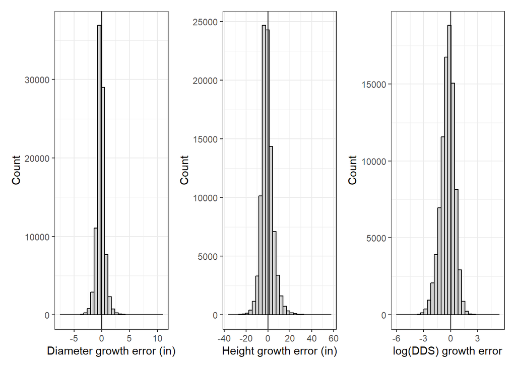

```r
dg_err_dist <- trees_err |>
  ggplot()+
  geom_histogram(aes(x = dg_err), color = 'black', fill = 'lightgrey')+
  labs(x = 'Diameter growth error (in)',
       y = 'Count')

hg_err_dist <- trees_err |>
  ggplot()+
  geom_histogram(aes(x = hg_err), color = 'black', fill = 'lightgrey')+
  labs(x = 'Height growth error (in)',
       y = 'Count')

ldds_err_dist <- trees_err |>
  ggplot()+
  geom_histogram(aes(x = ldds_err), color = 'black', fill = 'lightgrey')+
  labs(x = 'log(DDS) growth error',
       y = 'Count')

dg_err_dist+hg_err_dist+ldds_err_dist&theme_bw()&geom_vline(aes(xintercept = 0))
```

Diameter growth errors are generally small but the center of the distribution is less than 0, indicating general overprediction of diameter growth. Height error is much more variable (see scale of x-axis) and again appears to be slightly off-center, though it’s hard to tell. Height error may be a little skewed, but both look relatively normal which is a good sign because that is an FVS assumption. In contrast log(DDS) growth error is more skewed, with a longer tail to the left of the mode of the distribution.

The joint diameter and height error distribution is also worth looking it. However, there are some trees with extremely large errors that make the joint picture “zoomed out,” so we’ll do a version with those removed by filtering out observations outside of the 1.5*IQR range. I’ll also scale the axes by SD so that they’re on comparable scales and I can use a fixed aspect ratio to better look at the shape of the joint distribution without it being confounded with the different scales of the variables.

**Code to generate figure**

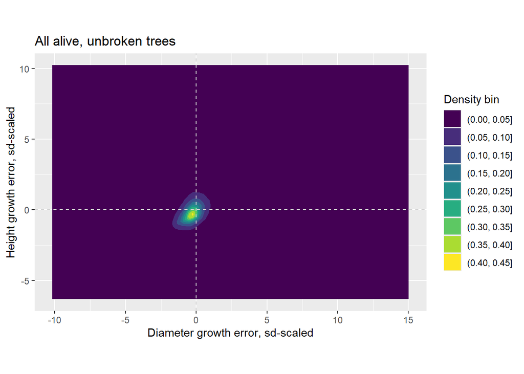

```r
survivors_summ <- trees_err |>
  summarize(dg_lquant = quantile(dg_err, 0.25),
            dg_uquant = quantile(dg_err, 0.75),
            hg_lquant = quantile(hg_err, 0.25),
            hg_uquant = quantile(hg_err, 0.75),
            ldds_lquant = quantile(ldds_err, 0.25, na.rm = TRUE),
            ldds_uquant = quantile(ldds_err, 0.75, na.rm = TRUE))
survivors_summ$dg_iqr <- survivors_summ$dg_uquant-survivors_summ$dg_lquant
survivors_summ$hg_iqr <- survivors_summ$hg_uquant-survivors_summ$hg_lquant
survivors_summ$ldds_iqr <- survivors_summ$ldds_uquant-survivors_summ$ldds_lquant

trees_err |>
  ggplot()+
  geom_density_2d_filled(aes(x = dg_err/sd(dg_err), y = hg_err/sd(hg_err)))+
    geom_hline(aes(yintercept = 0), color = 'lightgrey', linetype = 'dashed')+
  geom_vline(aes(xintercept = 0), color = 'lightgrey', linetype = 'dashed')+
  coord_fixed()+
  labs(x = 'Diameter growth error, sd-scaled',
       y = 'Height growth error, sd-scaled',
       fill = 'Density bin',
       title = 'All alive, unbroken trees')
```

**Code to generate figure**

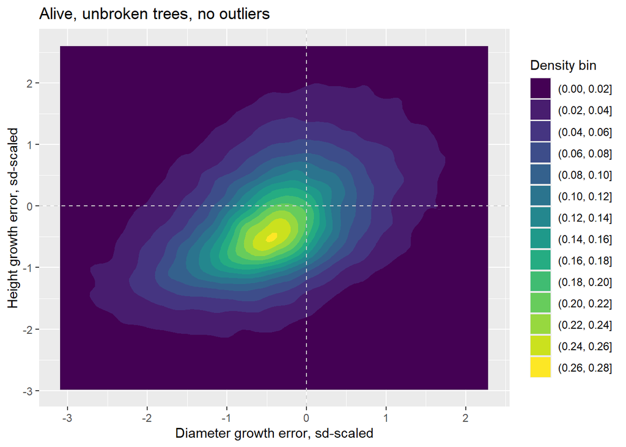

```r
trees_err |>
  filter(dg_err >= survivors_summ$dg_lquant-1.5*survivors_summ$dg_iqr,
         dg_err <= survivors_summ$dg_uquant+1.5*survivors_summ$dg_iqr,
         hg_err >= survivors_summ$hg_lquant-1.5*survivors_summ$hg_iqr,
         hg_err <= survivors_summ$hg_uquant+1.5*survivors_summ$hg_iqr) |>
  ggplot()+
  geom_density_2d_filled(aes(x = dg_err/sd(dg_err), y = hg_err/sd(hg_err)))+
    geom_hline(aes(yintercept = 0), color = 'lightgrey', linetype = 'dashed')+
  geom_vline(aes(xintercept = 0), color = 'lightgrey', linetype = 'dashed')+
  labs(x = 'Diameter growth error, sd-scaled',
       y = 'Height growth error, sd-scaled',
       fill = 'Density bin',
       title = 'Alive, unbroken trees, no outliers')
```

**Code to generate figure**

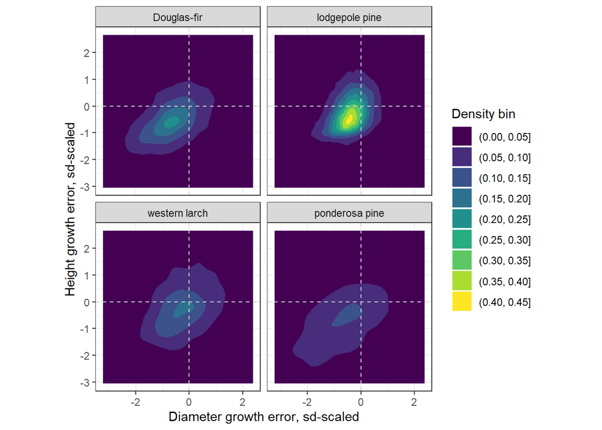

```r
trees_err |>
  filter(dg_err >= survivors_summ$dg_lquant-1.5*survivors_summ$dg_iqr,
         dg_err <= survivors_summ$dg_uquant+1.5*survivors_summ$dg_iqr,
         hg_err >= survivors_summ$hg_lquant-1.5*survivors_summ$hg_iqr,
         hg_err <= survivors_summ$hg_uquant+1.5*survivors_summ$hg_iqr,
         common_name %in% study_sps) |>
  ggplot()+
  geom_density_2d_filled(aes(x = dg_err/(sd(dg_err)), y = hg_err/(sd(hg_err))))+
  geom_hline(aes(yintercept = 0), color = 'lightgrey', linetype = 'dashed')+
  geom_vline(aes(xintercept = 0), color = 'lightgrey', linetype = 'dashed')+
  facet_wrap(facets = vars(common_name))+
  theme_bw()+
  coord_fixed()+
  labs(x = 'Diameter growth error, sd-scaled',
       y = 'Height growth error, sd-scaled',
       fill = 'Density bin')
```

Splitting it out by species like this shows that the relationship we see in the unsplit version is probably at least somewhat influenced by how species. Yet, most species show a similar pattern. We don’t see a bunch of nice, round-looking distributions that when you combine them they make that diagonal blob. Instead, it’s a bunch of diagonal blobs that when combined make another diagonal blob. Western larch actually looks pretty good, though it’s a bit diffuse.

It’s also interesting how much more dense lodgepole error is relative to Doug fir, which is quite a bit more diffuse over the space. It looks like FVS is more consistently wrong with lodgepole than with Doug fir. All this is good to put in our back pocket to consider whether we should be calibrating diameter alone or both, and whether our model should consider both at once. A nice part about this diagonal blob shape is that bringing diameter growth error closer to 0 also brings height growth error closer to 0. As Dave pointed out, if it went the other way but the center of mass was in the same place, bringing diameter growth error from negative towards 0 would make height growth error get worse (more negative).

### Error relationships

This dataframe will be used for adding annotations:

```r
median_errs <- trees_err |>
  filter(common_name %in% study_sps) |>
  summarize(med_dg_err = median(dg_err),
            med_hg_err = median(hg_err),
            med_ldds_err = median(ldds_err),
            .by = common_name) |>
  # bounds where growth estimates are weighted
  mutate(weight_lower = case_when(common_name == 'lodgepole pine' ~ 1,
                                  .default = 2),
         weight_upper = case_when(common_name == 'lodgepole pine' ~ 5,
                                  .default = 10))
```

**Code to generate figure**

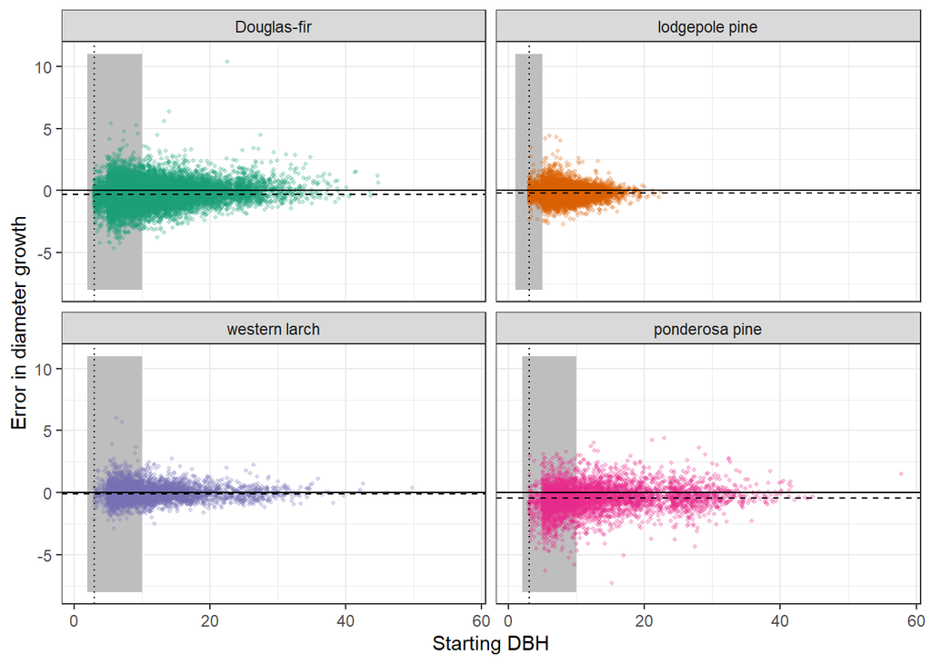

```r
trees_err |>
  filter(common_name %in% study_sps) |>
  ggplot()+
  # shade in the region where prediction will be influenced by large tree model
  geom_rect(data = median_errs, aes(xmin = weight_lower, xmax = weight_upper,
                                    ymin = -8, ymax = 11),
            fill = 'grey')+
  geom_point(aes(x = fia_dbh_1, y = dg_err, color = common_name),
             alpha = 0.25, size = 0.75)+
  geom_hline(aes(yintercept = 0))+
  # everything to the left of this is a "small tree" and was grown height-first
  geom_vline(aes(xintercept = 3), lty = 'dotted')+
  geom_hline(data = median_errs, aes(yintercept = med_dg_err),
             linetype = 'dashed')+
  facet_wrap(facets = vars(common_name))+
  theme_bw()+
  theme(legend.position = 'none',
        panel.background = element_rect(fill = NA))+
  scale_color_brewer(palette = 'Dark2')+
  scale_y_continuous(limits = c(-8, 11))+
  labs(x = 'Starting DBH', y = 'Error in diameter growth', color = 'Species')
```

After what I saw with the diameter growth discontinuity, I’ll take the pattern of trees < 5” DBH with a grain of salt because it may just be a sample size issue. Generally, it looks like diameter growth error decreases with tree size, and median error is below 0.

Relative error is also worth looking at. That is, how bad are the errors relative to the actual measurement? For example, a 2-inch difference is pretty bad for a tree that’s 5”, but not bad for a tree that has a DBH of 40” or more. Based on the error vs starting DBH relationship above, I expect relative error to decrease as starting DBH increases.

**Code to generate figure**

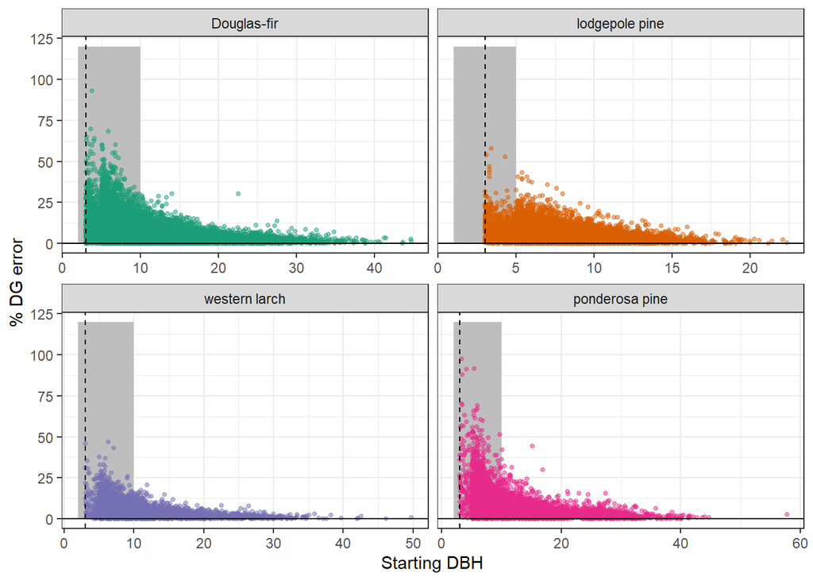

```r
trees_err |>
  filter(common_name %in% study_sps) |>
  mutate(rel_dg_err = 100*abs(dg_err/fia_dbh_2)) |>
  ggplot()+
  # shade in the region where prediction will be influenced by large tree model
  geom_rect(data = median_errs, aes(xmin = weight_lower, xmax = weight_upper,
                                    ymin = 0, ymax = 120),
            fill = 'grey')+
  geom_point(aes(x = fia_dbh_1, y = rel_dg_err, color = common_name),
             alpha = 0.5, size = 1)+
  geom_hline(aes(yintercept = 0))+
  geom_vline(aes(xintercept = 3), lty = 'dashed')+
  facet_wrap(facets = vars(common_name), scales = 'free_x')+
  theme_bw()+
  theme(legend.position = 'none')+
  scale_color_brewer(palette = 'Dark2')+
  labs(x = 'Starting DBH', y = '% DG error')
```

To reduce the amount of information here, I’ll plot just the median relative error at each DBH value for each species so that there is less overplotting.

**Code to generate figure**

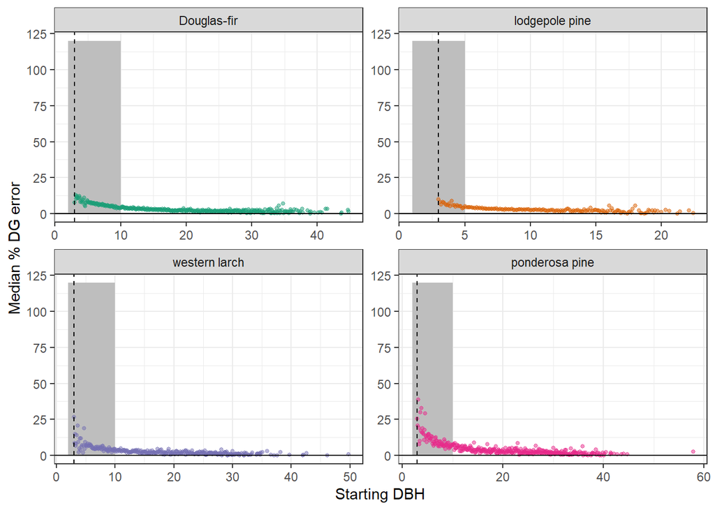

```r
trees_err |>
  filter(common_name %in% study_sps) |>
  mutate(rel_dg_err = 100*abs(dg_err/fia_dbh_2)) |>
  summarize(med_err = median(rel_dg_err), .by = c(fia_dbh_1, common_name)) |>
  ggplot()+
  # shade in the region where prediction will be influenced by large tree model
  geom_rect(data = median_errs, aes(xmin = weight_lower, xmax = weight_upper,
                                    ymin = 0, ymax = 120),
            fill = 'grey')+
  geom_point(aes(x = fia_dbh_1, y = med_err, color = common_name),
             alpha = 0.5, size = 1)+
  geom_hline(aes(yintercept = 0))+
  geom_vline(aes(xintercept = 3), lty = 'dashed')+
  facet_wrap(facets = vars(common_name), scales = 'free')+
  theme_bw()+
  theme(legend.position = 'none')+
  scale_color_brewer(palette = 'Dark2')+
  labs(x = 'Starting DBH', y = 'Median % DG error')
```

I can make the same plots for height error:

**Code to generate figure**

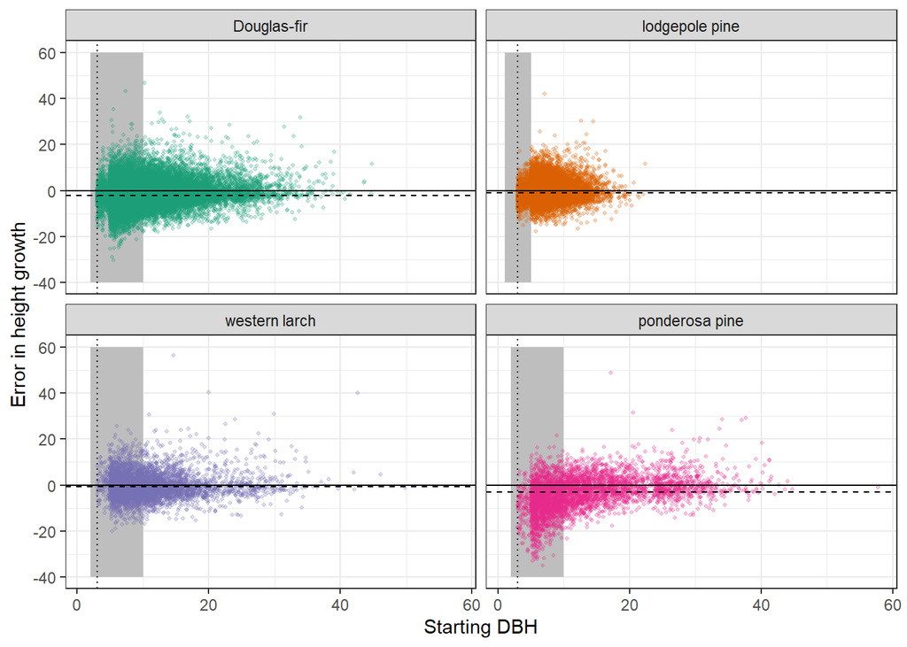

```r
trees_err |>
  filter(common_name %in% study_sps) |>
  ggplot()+
  # shade in the region where prediction will be influenced by large tree model
  geom_rect(data = median_errs, aes(xmin = weight_lower, xmax = weight_upper,
                                    ymin = -40, ymax = 60),
            fill = 'grey')+
  geom_point(aes(x = fia_dbh_1, y = hg_err, color = common_name),
             alpha = 0.25, size = 0.75)+
  geom_hline(aes(yintercept = 0))+
  # everything to the left of this is a "small tree" and was grown height-first
  geom_vline(aes(xintercept = 3), lty = 'dotted')+
  geom_hline(data = median_errs, aes(yintercept = med_hg_err),
             linetype = 'dashed')+
  facet_wrap(facets = vars(common_name))+
  theme_bw()+
  theme(legend.position = 'none',
        panel.background = element_rect(fill = NA))+
  scale_color_brewer(palette = 'Dark2')+
  labs(x = 'Starting DBH', y = 'Error in height growth', color = 'Species')
```

Height error is much larger and more variable.

**Code to generate figure**

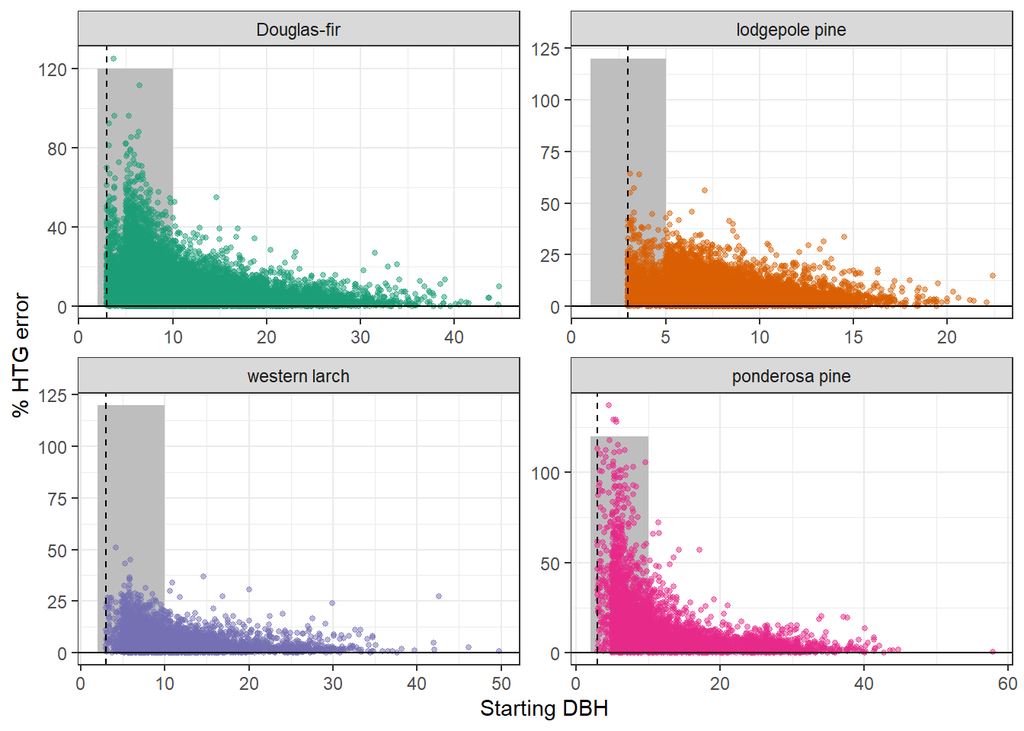

```r
trees_err |>
  filter(common_name %in% study_sps) |>
  mutate(rel_htg_err = 100*abs(hg_err/fia_ht_2)) |>
 # summarize(med_err = median(rel_htg_err), .by = c(fia_dbh_1, common_name)) |>
  ggplot()+
  # shade in the region where prediction will be influenced by large tree model
  geom_rect(data = median_errs, aes(xmin = weight_lower, xmax = weight_upper,
                                    ymin = 0, ymax = 120),
            fill = 'grey')+
  geom_point(aes(x = fia_dbh_1, y = rel_htg_err, color = common_name),
             alpha = 0.5, size = 1)+
  geom_hline(aes(yintercept = 0))+
  geom_vline(aes(xintercept = 3), lty = 'dashed')+
  facet_wrap(facets = vars(common_name), scales = 'free')+
  theme_bw()+
  theme(legend.position = 'none')+
  scale_color_brewer(palette = 'Dark2')+
  labs(x = 'Starting DBH', y = '% HTG error')
```

Like with DBH error, relative height growth error decreases as trees get larger. I’ll do the same thing of plotting the median relative height growth error for each starting DBH and each species, just to make it a bit easier to see the overall patterns here.

**Code to generate figure**

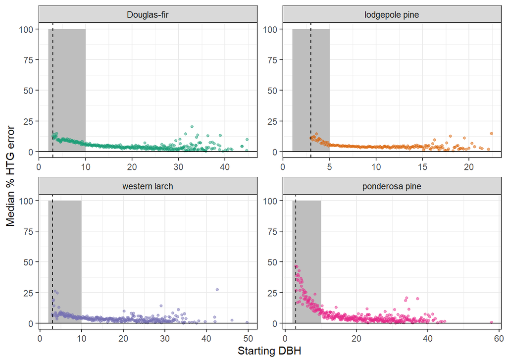

```r
trees_err |>
  filter(common_name %in% study_sps) |>
  mutate(rel_htg_err = 100*abs(hg_err/fia_ht_2)) |>
  summarize(med_err = median(rel_htg_err), .by = c(fia_dbh_1, common_name)) |>
  ggplot()+
  # shade in the region where prediction will be influenced by large tree model
  geom_rect(data = median_errs, aes(xmin = weight_lower, xmax = weight_upper,
                                    ymin = 0, ymax = 100),
            fill = 'grey')+
  geom_point(aes(x = fia_dbh_1, y = med_err, color = common_name),
             alpha = 0.5, size = 1)+
  geom_hline(aes(yintercept = 0))+
  geom_vline(aes(xintercept = 3), lty = 'dashed')+
  facet_wrap(facets = vars(common_name), scales = 'free')+
  theme_bw()+
  theme(legend.position = 'none')+
  scale_color_brewer(palette = 'Dark2')+
  labs(x = 'Starting DBH', y = 'Median % HTG error')
```

## Mapping

First, need to turn stand-level error measurements into spatial data.

```r
stand_err_spat <- st_as_sf(stand_err, coords = c('LONGITUDE', 'LATITUDE'),
                           crs = 'epsg:4269') |>
  st_transform(crs = st_crs(ie_buffered))
stand_sp_err_spat <- st_as_sf(stand_sp_err, coords = c('LONGITUDE', 'LATITUDE'),
                              crs = 'epsg:4269')
```

Now, we can make some maps!

### Habitat types and EPA hexes

**Code to generate figure**

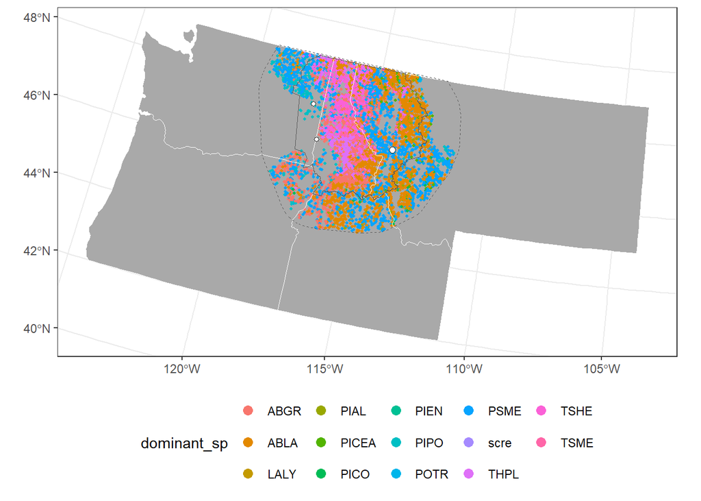

```r
stand_err_spat |>
  ggplot()+
  geom_sf(data = states, fill = 'darkgrey')+
  geom_sf(aes(color = dominant_sp), size = 0.75)+
  geom_sf(data = states, color = 'white', fill = NA)+
  geom_sf(data = ie, fill = NA)+
  geom_sf(data = ie_buffered, linetype = 'dashed', fill = NA)+
  geom_sf(data = missoula, size = 2, pch = 21, fill = 'white')+
  geom_sf(data = spokane, size = 1.5, pch = 21, fill = 'white')+
  geom_sf(data = moscow, size = 1.5, pch = 21, fill = 'white')+
  theme_bw()+
  theme(legend.position = 'bottom')+
  guides(color = guide_legend(override.aes = list(size = 3)))
```

Same, but as a raster with the majority habitat type filling each cell:

**Code to generate figure**

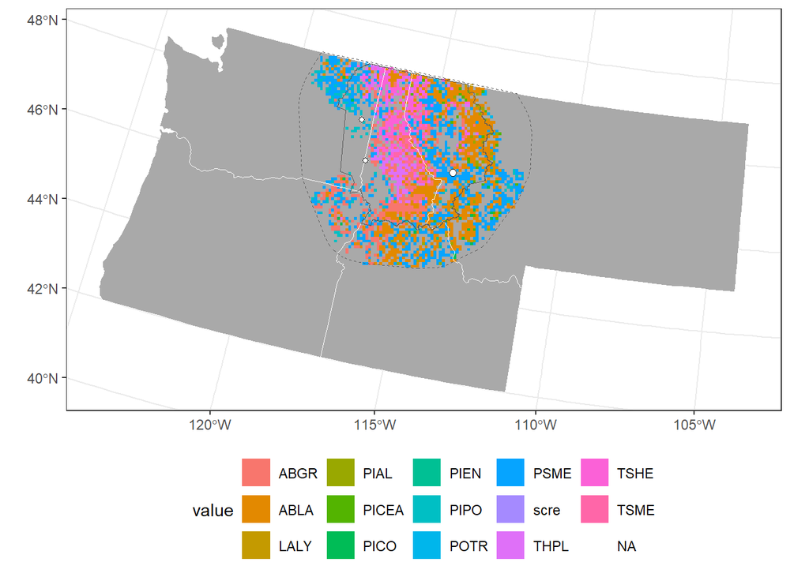

```r
template <- terra::rast(nrows = 75, ncols = 75, nlyrs = 1,
                        crs = terra::crs(terra::vect(stand_err_spat)),
                        extent = terra::ext(terra::vect(stand_err_spat)))
habtype_raster <- terra::rasterize(terra::vect(stand_err_spat), template,
                                   field = 'dominant_sp')

ggplot()+
  geom_sf(data = states, fill = 'darkgrey')+
  geom_spatraster(data = habtype_raster)+
  geom_sf(data = states, color = 'white', fill = NA)+
  geom_sf(data = ie, fill = NA)+
  geom_sf(data = ie_buffered, linetype = 'dashed', fill = NA)+
  geom_sf(data = missoula, size = 2, pch = 21, fill = 'white')+
  geom_sf(data = spokane, size = 1.5, pch = 21, fill = 'white')+
  geom_sf(data = moscow, size = 1.5, pch = 21, fill = 'white')+
  theme_bw()+
  theme(legend.position = 'bottom')+
  scale_fill_discrete(na.value = NA)+
  guides(color = guide_legend(override.aes = list(size = 3)))
```

but grouping the less common habitat types together to reduce the number of colors:

```r
hab_frequencies <- stand_err |>
  group_by(dominant_sp) |>
  tally() |>
  arrange(desc(n))

hab_frequencies
```

| dominant_sp | n |
| --- | --- |
| ABLA | 1374 |
| PSME | 1289 |
| ABGR | 667 |
| THPL | 377 |
| TSHE | 363 |
| PIPO | 165 |
| TSME | 133 |
| PIAL | 59 |
| PICEA | 45 |
| PICO | 33 |
| LALY | 11 |
| POTR | 10 |
| PIEN | 4 |
| scre | 4 |